# MPDW-Regresi Deret Waktu

#Packages

```r
library(rmdformats)
library(readxl)
library(GGally)
library(psych)
library(car)
library(TTR)
```

```r
library(carData)
library(corrplot)
library(dplyr)
library(stargazer)
library(olsrr)
library(lmtest)
library(orcutt) #untuk membuat model regresi Cochrane-Orcutt
library(HoRM) #untuk membuat model regresi Hildreth-Lu
```

# Import Data

```r
data <- read_excel("~/Kuliah/Semester 5/MPDW/Data IPM NTT 2010-2024.xlsx")
data
```

```
## # A tibble: 15 × 2
##    Tahun Nilai
##    <dbl> <dbl>
##  1  2010  61.2
##  2  2011  62.1
##  3  2012  63.0
##  4  2013  63.8
##  5  2014  64.3
##  6  2015  65.2
##  7  2016  65.8
##  8  2017  66.6
##  9  2018  67.3
## 10  2019  68.1
## 11  2020  68.2
## 12  2021  68.6
## 13  2022  69.5
## 14  2023  70.2
## 15  2024  70.9
```

```r
#Membentuk objek time series
data.ts<-ts(data$Nilai)
data.ts
```

```
## Time Series:
## Start = 1
## End = 15
## Frequency = 1
##  [1] 61.16 62.14 62.98 63.76 64.31 65.19 65.81 66.58 67.30 68.14 68.25 68.65
## [13] 69.46 70.20 70.93
```

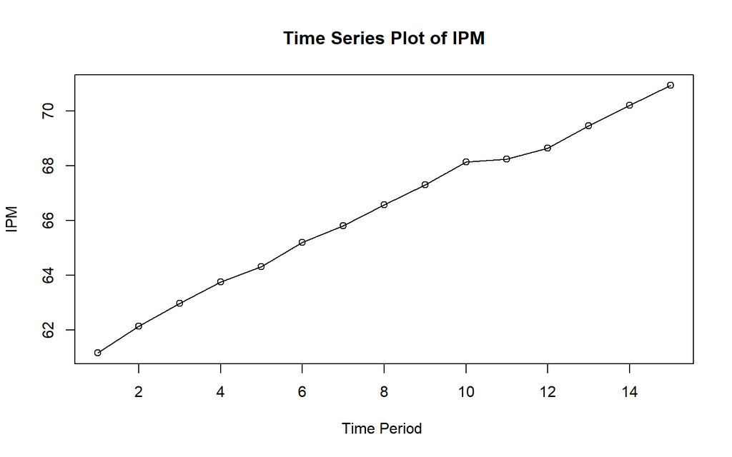

```r
#Membuat plot time series
ts.plot(data.ts, xlab="Time Period ", ylab="IPM", main= "Time Series Plot of IPM")
points(data.ts)
```

```r
dt.sma <- SMA(data.ts, n=3)
dma <- SMA(dt.sma, n = 3)
At <- 2*dt.sma - dma
Bt <- 2/(3-1)*(dt.sma - dma)
dt.dma<- At+Bt
dt.ramal<- c(NA, dt.dma)

t = 1:5
f = c()

for (i in t) {
  f[i] = At[length(At)] + Bt[length(Bt)]*(i)
}
```

```r
dt.gab <- cbind(aktual = c(data.ts,rep(NA,5)),
                pemulusan1 = c(dt.sma,rep(NA,5)),
                pemulusan2 = c(dt.dma, rep(NA,5)),
                At = c(At, rep(NA,5)),
                Bt = c(Bt,rep(NA,5)),
                ramalan = c(dt.ramal, f[-1]))
dt.gab
```

```
##       aktual pemulusan1 pemulusan2       At        Bt  ramalan
##  [1,]  61.16         NA         NA       NA        NA       NA
##  [2,]  62.14         NA         NA       NA        NA       NA
##  [3,]  62.98   62.09333         NA       NA        NA       NA
##  [4,]  63.76   62.96000         NA       NA        NA       NA
##  [5,]  64.31   63.68333   65.22556 64.45444 0.7711111       NA
##  [6,]  65.19   64.42000   65.88444 65.15222 0.7322222 65.22556
##  [7,]  65.81   65.10333   66.50556 65.80444 0.7011111 65.88444
##  [8,]  66.58   65.86000   67.32444 66.59222 0.7322222 66.50556
##  [9,]  67.30   66.56333   68.00556 67.28444 0.7211111 67.32444
## [10,]  68.14   67.34000   68.84444 68.09222 0.7522222 68.00556
## [11,]  68.25   67.89667   69.15667 68.52667 0.6300000 68.84444
## [12,]  68.65   68.34667   69.31778 68.83222 0.4855556 69.15667
## [13,]  69.46   68.78667   69.67333 69.23000 0.4433333 69.31778
## [14,]  70.20   69.43667   70.59667 70.01667 0.5800000 69.67333
## [15,]  70.93   70.19667   71.64333 70.92000 0.7233333 70.59667
## [16,]     NA         NA         NA       NA        NA 71.64333
## [17,]     NA         NA         NA       NA        NA 72.36667
## [18,]     NA         NA         NA       NA        NA 73.09000
## [19,]     NA         NA         NA       NA        NA 73.81333
## [20,]     NA         NA         NA       NA        NA 74.53667
```

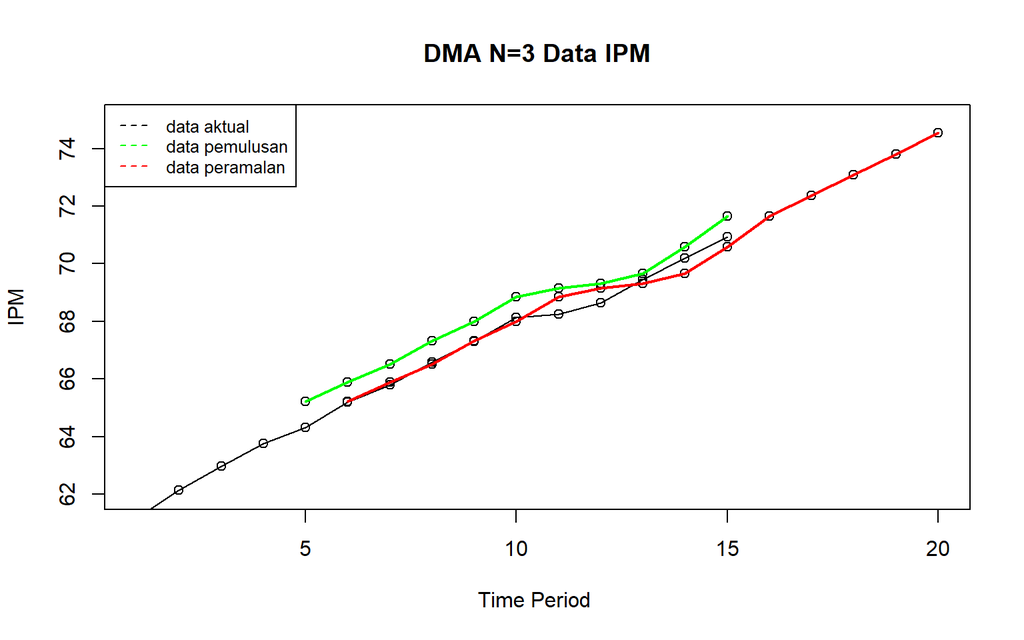

```r
#Plot time series
ts.plot(dt.gab[,1], xlab="Time Period ", ylab="IPM",
        main= "DMA N=3 Data IPM", ylim=c(62,75))
points(dt.gab[,1])
points(dt.gab[,3])
points(dt.gab[,6])
lines(dt.gab[,3],col="green",lwd=2)
lines(dt.gab[,6],col="red",lwd=2)
legend("topleft",c("data aktual","data pemulusan","data peramalan"),
       lty=8, col=c("black","green","red"), cex=0.8)
```

# Eksplorasi Data

```r
summary(data)
```

```
##      Tahun          Nilai
##  Min.   :2010   Min.   :61.16
##  1st Qu.:2014   1st Qu.:64.03
##  Median :2017   Median :66.58
##  Mean   :2017   Mean   :66.32
##  3rd Qu.:2020   3rd Qu.:68.45
##  Max.   :2024   Max.   :70.93
```

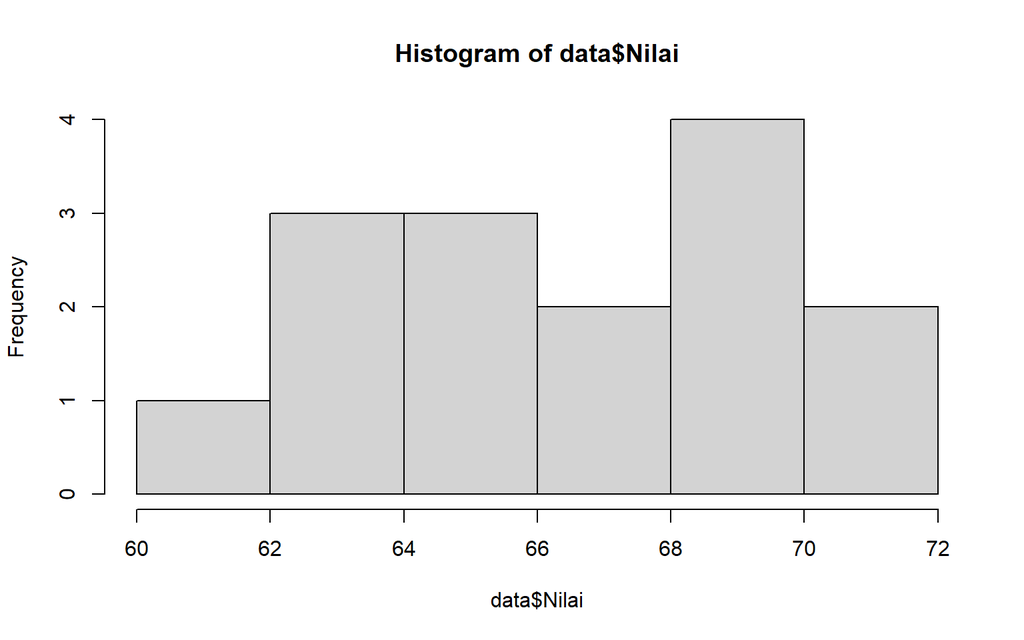

```r
hist(data$Nilai)
```

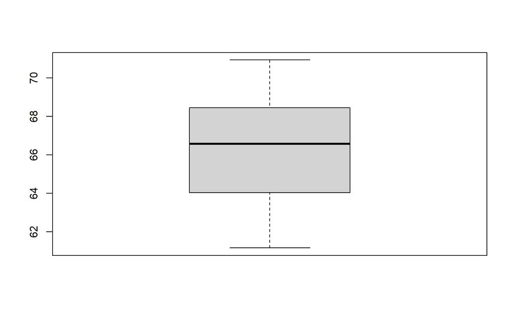

```r
boxplot(data$Nilai)
```

# Pembangunan Model Regresi

```r
# Model regresi deret waktu: IPM terhadap Tahun
model_ipm <- lm(Nilai ~ Tahun, data = data)

# Ringkasan hasil regresi
summary(model_ipm)
```

```
##
## Call:
## lm(formula = Nilai ~ Tahun, data = data)
##
## Residuals:
##      Min       1Q   Median       3Q      Max
## -0.46600 -0.15400 -0.00057  0.18271  0.47371
##
## Coefficients:
##               Estimate Std. Error t value Pr(>|t|)
## (Intercept) -1.287e+03  3.212e+01  -40.08 5.23e-15 ***
## Tahun        6.711e-01  1.593e-02   42.14 2.73e-15 ***
## ---
## Signif. codes:  0 '***' 0.001 '**' 0.01 '*' 0.05 '.' 0.1 ' ' 1
##
## Residual standard error: 0.2665 on 13 degrees of freedom
## Multiple R-squared:  0.9927, Adjusted R-squared:  0.9922
## F-statistic:  1776 on 1 and 13 DF,  p-value: 2.733e-15
```

Berdasarkan hasil analisis regresi linear, diperoleh model sebagai berikut:

$$\hat{Y} = -1287.0 + 0.6711 \, X$$

Koefisien tahun memiliki nilai p yang sangat kecil $(p = 2.73 \times 10^{-15} < 0.05)$, sehingga signifikan pada taraf nyata $5\%$. Hal ini menunjukkan bahwa setiap peningkatan satu tahun memberikan kenaikan rata-rata sebesar:

$$\Delta \hat{Y} = 0.6711$$

pada variabel nilai. Selain itu, nilai koefisien determinasi sebesar:

$$R^2 = 99.27\%$$

menunjukkan bahwa model mampu menjelaskan $99.27\%$ variasi pada data. Dengan demikian, model regresi ini tergolong sangat baik untuk memprediksi perkembangan nilai berdasarkan tahun.

# Asumsi Klasik

## Eksplorasi sisaan

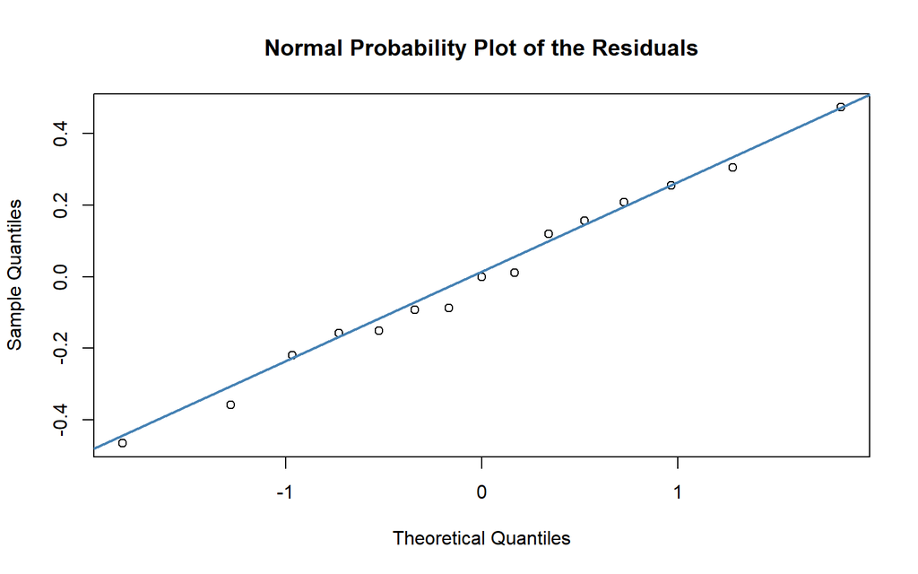

```r
# Residuals
resid <- residuals(model_ipm)
fitted <- fitted.values(model_ipm)

# 1. Normal Probability Plot (QQ Plot)
qqnorm(resid, main="Normal Probability Plot of the Residuals")
qqline(resid, col = "steelblue", lwd = 2)
```

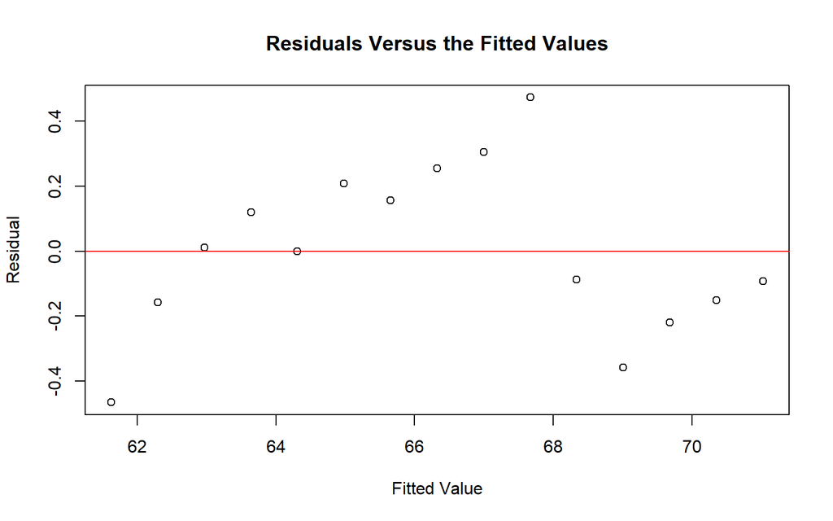

```r
# 2. Residuals vs Fitted
plot(fitted, resid,
     xlab="Fitted Value", ylab="Residual",
     main="Residuals Versus the Fitted Values")
abline(h=0, col="red")
```

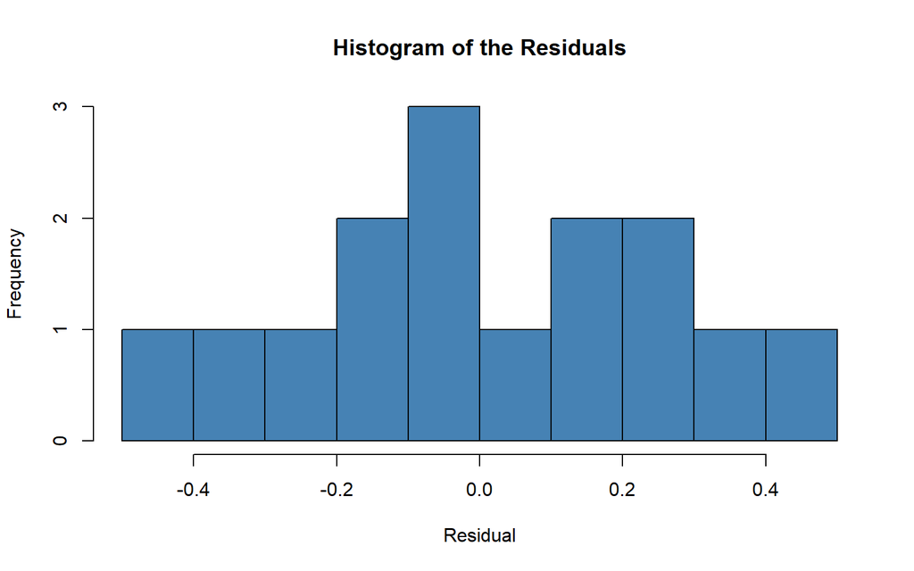

```r
# 3. Histogram Residuals
hist(resid, breaks=10, col="steelblue",
     main="Histogram of the Residuals", xlab="Residual")
```

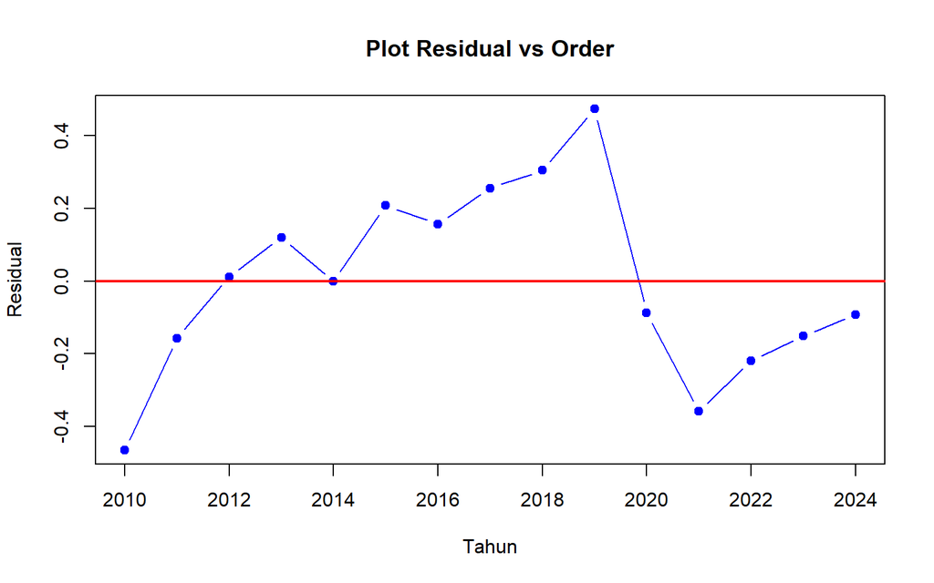

```r
# 4. Residuals vs Order
plot(data$Tahun, resid, type = "b",
     col = "blue", pch = 19,
     main = "Plot Residual vs Order",
     xlab = "Tahun", ylab = "Residual")
abline(h = 0, col = "red", lwd = 2)
```

## Uji Formal

```r
#Melihat Sisaan Menyebar Normal/Tidak
#H0: sisaan mengikuti sebaran normal
#H1: sisaan tidak mengikuti sebaran normal
shapiro.test(resid)
```

```
##
##  Shapiro-Wilk normality test
##
## data:  resid
## W = 0.9886, p-value = 0.9986
```

```r
ks.test(resid, "pnorm", mean=mean(resid), sd=sd(resid))
```

```
##
##  Exact one-sample Kolmogorov-Smirnov test
##
## data:  resid
## D = 0.099913, p-value = 0.9946
## alternative hypothesis: two-sided
```

Berdasarkan uji formal Saphiro-Wilk dan Kolmogorov-Smirnov didapatkan nilai *p-value* > $\alpha$ (5%). Artinya, cukup bukti untuk menyatakan sisaan berdistribusi normal.

```r
#Deteksi autokorelasi dengan uji-Durbin Watson
#H0: tidak ada autokorelasi
#H1: ada autokorelasi
# Uji Durbin-Watson
dwtest(model_ipm)
```

```
##
##  Durbin-Watson test
##
## data:  model_ipm
## DW = 0.70757, p-value = 0.0004046
## alternative hypothesis: true autocorrelation is greater than 0
```

Dengan Uji formal durbin watson dengan nilai p-value lebih kecil dari taraf (Tolak H0) mengindikasikan adanya autokorelasi, sehingga model harus di transformasi terlebih dahulu

## Plot ACF

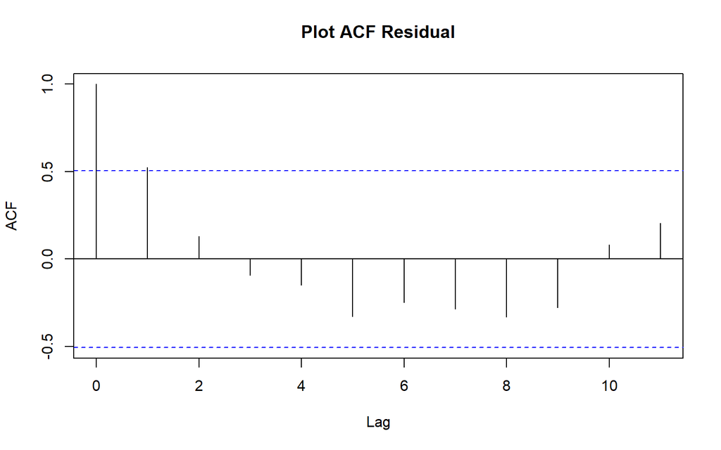

```r
acf(resid, main = "Plot ACF Residual")
```

## Plot PACF

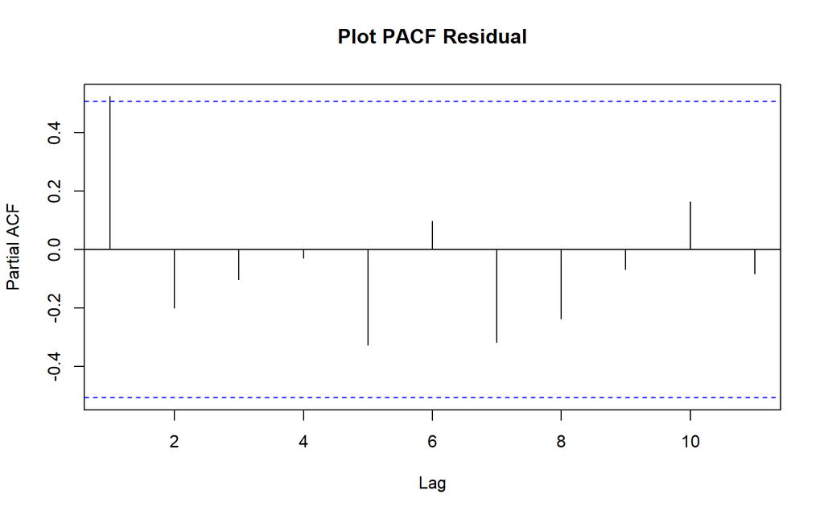

```r
pacf(resid, main = "Plot PACF Residual")
```

# Penanganan Autokorelasi

## Metode Cochrane-Orcutt

Penanganan metode Cochrane-Orcutt dapat dilakukan dengan bantuan packages Orcutt pada aplikasi `R` maupun secara manual. Berikut ini ditampilkan cara menggunakan bantuan `library` *packages* `Orcutt`.

```r
#Penanganan Autokorelasi Cochrane-Orcutt
modelCO<-cochrane.orcutt(model_ipm)
modelCO
```

```
## Cochrane-orcutt estimation for first order autocorrelation
##
## Call:
## lm(formula = Nilai ~ Tahun, data = data)
##
##  number of interaction: 17
##  rho 0.538696
##
## Durbin-Watson statistic
## (original):    0.70757 , p-value: 4.046e-04
## (transformed): 1.82440 , p-value: 2.51e-01
##
##  coefficients:
##  (Intercept)        Tahun
## -1212.929938     0.634298
```

Hasil keluaran model setelah dilakukan penanganan autokorelasi dengan metode Cochrane-Orcutt adalah sebagai berikut:
$$y_i=−1212.929938+0.634298x_t$$
Hasil juga menunjukkan bahwa nilai Durbin-Watson (DW) dan p-value meningkat menjadi 1.82440 dan 0.251. Nilai DW sudah berada pada rentang DU < DW < 4-DU atau $1.331 < DW < 2.669$. Hal tersebut juga didukung dengan nilai *p-value* > 0.05, artinya belum cukup bukti menyatakan bahwa sisaan terdapat autokorelasi pada taraf nyata 5%. Untuk nilai $ρ ̂$ optimum yang digunakan adalah$ 0.5386964$.

```r
#Rho optimum
rho<- modelCO$rho
rho
```

```
## [1] 0.5386963
```

Selanjutnya akan dilakukan transformasi secara manual dengan syntax berikut ini.

```r
IPM <- data$Nilai
Tahun <- data$Tahun
```

```r
IPM[-1]
```

```
##  [1] 62.14 62.98 63.76 64.31 65.19 65.81 66.58 67.30 68.14 68.25 68.65 69.46
## [13] 70.20 70.93
```

```r
#Transformasi Manual
IPM.trans<- IPM[-1]-IPM[-15]*rho
Tahun.trans<- Tahun[-1]-Tahun[-15]*rho
modelCOmanual<- lm(IPM.trans~Tahun.trans)
summary(modelCOmanual)
```

```
##
## Call:
## lm(formula = IPM.trans ~ Tahun.trans)
##
## Residuals:
##      Min       1Q   Median       3Q      Max
## -0.32987 -0.04146  0.01411  0.11733  0.30524
##
## Coefficients:
##               Estimate Std. Error t value Pr(>|t|)
## (Intercept) -559.52907   23.56971  -23.74 1.87e-11 ***
## Tahun.trans    0.63430    0.02531   25.06 9.88e-12 ***
## ---
## Signif. codes:  0 '***' 0.001 '**' 0.01 '*' 0.05 '.' 0.1 ' ' 1
##
## Residual standard error: 0.1761 on 12 degrees of freedom
## Multiple R-squared:  0.9813, Adjusted R-squared:  0.9797
## F-statistic:   628 on 1 and 12 DF,  p-value: 9.879e-12
```

```r
#Mencari Penduga Koefisien Regresi setelah Transformasi ke Persamaan Awal
b0bintang <- modelCOmanual$coefficients[-2]
b0 <- b0bintang/(1-rho)
b1 <- modelCOmanual$coefficients[-1]
b0
```

```
## (Intercept)
##    -1212.93
```

```r
b1
```

```
## Tahun.trans
##   0.6342984
```

Hasil perhitungan koefisien regresi tersebut akan menghasilkan hasil yang sama dengan model yang dihasilkan menggunakan *packages*.

## Metode Hildreth-Lu

Penanganan kedua adalah menggunakan metode Hildreth-Lu. Metode ini akan mencari nilai SSE terkecil dan dapat dicari secara manual maupun menggunakan packages. Jika menggunakan packages, gunakan `library` *packages* `HORM`.

```r
library(HoRM)

# ambil y dan x (satu prediktor saja)
y <- data$Nilai
x <- data$Tahun

# grid search rho 0–0.9
r <- seq(0, 0.9, by = 0.1)
tab <- data.frame(
  rho = r,
  SSE = sapply(r, function(rr) deviance(hildreth.lu(y, x, rr)))
)

tab            # tabel rho vs SSE
```

```
##    rho       SSE
## 1  0.0 0.6368347
## 2  0.1 0.5476933
## 3  0.2 0.4767925
## 4  0.3 0.4241324
## 5  0.4 0.3897130
## 6  0.5 0.3735342
## 7  0.6 0.3755960
## 8  0.7 0.3958986
## 9  0.8 0.4344418
## 10 0.9 0.4912256
```

```r
rho_hat <- tab$rho[which.min(tab$SSE)]   # rho terbaik
fit_hl  <- hildreth.lu(y, x, rho_hat)    # model final
summary(fit_hl)
```

```
##
## Call:
## lm(formula = y ~ x)
##
## Residuals:
##      Min       1Q   Median       3Q      Max
## -0.31209 -0.05603  0.00714  0.11807  0.31660
##
## Coefficients:
##               Estimate Std. Error t value Pr(>|t|)
## (Intercept) -609.58507   23.61095  -25.82 6.95e-12 ***
## x              0.63738    0.02339   27.25 3.68e-12 ***
## ---
## Signif. codes:  0 '***' 0.001 '**' 0.01 '*' 0.05 '.' 0.1 ' ' 1
##
## Residual standard error: 0.1764 on 12 degrees of freedom
## Multiple R-squared:  0.9841, Adjusted R-squared:  0.9828
## F-statistic: 742.3 on 1 and 12 DF,  p-value: 3.682e-12
```

```r
#Penanganan Autokorelasi Hildreth lu
# Hildreth-Lu
hildreth.lu.func<- function(r, model_ipm){
  x <- model.matrix(model_ipm)[,-1]
  y <- model.response(model.frame(model_ipm))
  n <- length(y)
  t <- 2:n
  y <- y[t]-r*y[t-1]
  x <- x[t]-r*x[t-1]

  return(lm(y~x))
}

#Pencariab rho yang meminimumkan SSE
r <- c(seq(0.1,0.9, by= 0.1))
tab <- data.frame("rho" = r, "SSE" = sapply(r, function(i){deviance(hildreth.lu.func(i, model_ipm))}))
round(tab, 4)
```

```
##   rho    SSE
## 1 0.1 0.5477
## 2 0.2 0.4768
## 3 0.3 0.4241
## 4 0.4 0.3897
## 5 0.5 0.3735
## 6 0.6 0.3756
## 7 0.7 0.3959
## 8 0.8 0.4344
## 9 0.9 0.4912
```

Pertama-tama dilakukan pencarian nilai $ρ$ yang menghasilkan nilai SSE minimum. Dari hasil di atas terlihat bahwa nilai SSE terkecil terjadi pada saat $ρ = 0.5$ dengan nilai SSE sebesar 0.3735. Namun, hasil ini masih bersifat perkiraan karena jarak antar $ρ$ yang digunakan sebelumnya cukup besar, yaitu sebesar 0.1. Oleh karena itu, untuk memperoleh nilai $ρ$ yang lebih optimum, pencarian akan dilakukan kembali dengan tingkat ketelitian yang lebih tinggi. Kali ini, jarak antar $ρ$ yang dicari ditetapkan sebesar 0.001 dan dilakukan pada selang 0.4 sampai dengan 0.6.

```r
#Rho optimal di sekitar 0.5
rOpt <- seq(0.4,0.6, by= 0.001)
tabOpt <- data.frame("rho" = rOpt, "SSE" = sapply(rOpt, function(i){deviance(hildreth.lu.func(i, model_ipm))}))
head(tabOpt[order(tabOpt$SSE),])
```

```
##       rho       SSE
## 140 0.539 0.3721686
## 139 0.538 0.3721689
## 141 0.540 0.3721700
## 138 0.537 0.3721711
## 142 0.541 0.3721733
## 137 0.536 0.3721751
```

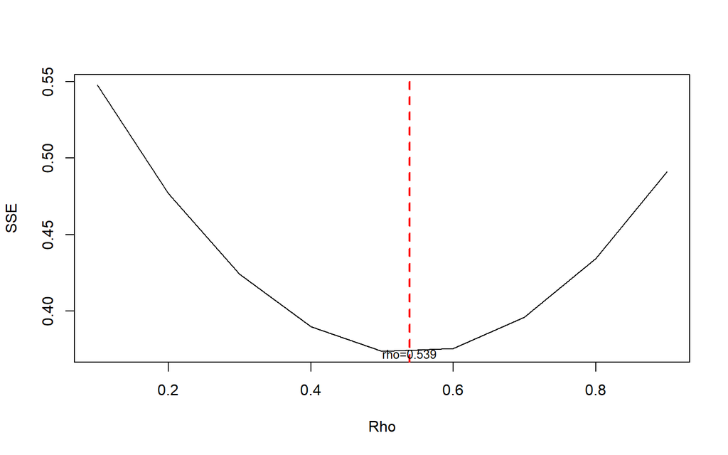

```r
#Grafik SSE optimum
par(mfrow = c(1,1))
plot(tab$SSE ~ tab$rho , type = "l", xlab = "Rho", ylab = "SSE")
abline(v = tabOpt[tabOpt$SSE==min(tabOpt$SSE),"rho"], lty = 2, col="red",lwd=2)
text(x=0.539, y=0.3721686, labels = "rho=0.539", cex = 0.8)
```

Perhitungan yang dilakukan aplikasi `R` menunjukkan bahwa nilai $ρ$ optimum, yaitu saat SSE terkecil terdapat pada nilai $ρ=0.539$. Hal tersebut juga ditunjukkan pada plot. Selanjutnya, model dapat didapatkan dengan mengevaluasi nilai $ρ$ ke dalam fungsi `hildreth.lu.func`, serta dilanjutkan dengan pengujian autokorelasi dengan uji Durbin-Watson. Namun, setelah pengecekan tersebut tidak lupa koefisien regresi tersebut digunakan untuk transformasi balik. Persamaan hasil transformasi itulah yang menjadi persamaan sesungguhnya.

```r
#Model terbaik
modelHL <- hildreth.lu.func(0.539, model_ipm)
summary(modelHL)
```

```
##
## Call:
## lm(formula = y ~ x)
##
## Residuals:
##      Min       1Q   Median       3Q      Max
## -0.33001 -0.04135  0.01416  0.11731  0.30515
##
## Coefficients:
##               Estimate Std. Error t value Pr(>|t|)
## (Intercept) -559.13621   23.56973  -23.72 1.89e-11 ***
## x              0.63427    0.02533   25.04 9.96e-12 ***
## ---
## Signif. codes:  0 '***' 0.001 '**' 0.01 '*' 0.05 '.' 0.1 ' ' 1
##
## Residual standard error: 0.1761 on 12 degrees of freedom
## Multiple R-squared:  0.9812, Adjusted R-squared:  0.9797
## F-statistic: 627.2 on 1 and 12 DF,  p-value: 9.96e-12
```

```r
#Transformasi Balik
cat("y = ", coef(modelHL)[1]/(0.539), "+", coef(modelHL)[2],"x", sep = "")
```

```
## y = -1037.358+0.6342721x
```

```r
#Deteksi autokorelasi
dwtest(modelHL)
```

```
##
##  Durbin-Watson test
##
## data:  modelHL
## DW = 1.8249, p-value = 0.2513
## alternative hypothesis: true autocorrelation is greater than 0
```

Terakhir, akan dibandingkan nilai SSE dari ketiga metode (metode awal, metode Cochrane-Orcutt, dan Hildreth-Lu).

```r
#Perbandingan
sseModelawal <- anova(model_ipm)$`Sum Sq`[-1]
sseModelCO <- anova(modelCOmanual)$`Sum Sq`[-1]
sseModelHL <- anova(modelHL)$`Sum Sq`[-1]
mseModelawal <- sseModelawal/length(IPM)
mseModelCO <- sseModelCO/length(IPM)
mseModelHL <- sseModelHL/length(IPM)
akurasi <- matrix(c(sseModelawal,sseModelCO,sseModelHL,
                    mseModelawal,mseModelCO,mseModelHL),nrow=2,ncol=3,byrow = T)
colnames(akurasi) <- c("Model Awal", "Model Cochrane-Orcutt", "Model Hildreth-Lu")
row.names(akurasi) <- c("SSE","MSE")
akurasi
```

```
##     Model Awal Model Cochrane-Orcutt Model Hildreth-Lu
## SSE 0.92319429            0.37216849        0.37216858
## MSE 0.06154629            0.02481123        0.02481124
```

Berdasarkan hasil tersebut dapat diketahui bahwa hasil penanganan autokorelasi dengan metode Cochrane-Orcutt dan Hildreth-Lu memiliki SSE yang hampir sama, sebesar $0.372$ dan lebih baik dibandingkan model awal ketika autokorelasi masih terjadi, yaitu sebesar $0.92319429$.

# Simpulan